# Lecture 8. Coding Best Practices

Zechariah Meunier

2025-04-23

## Folders and Filepaths

I like to organize my research projects with the following folder structure:

- Main Project Folder - everything lives here
  - [Repository Name] - everything that I want on GitHub
    - Code - code files in any language
    - Data - raw and processed data
      - One folder per data type
    - Figures & Tables - nicely-formatted graphs and summary tables
    - Results - statistical tables and quick R output
  - Data Entry & Scans - scanned datasheets and Excel spreadsheets for data entry and QA
  - Photos - photos of field sites, plots, experimental set up, etc.
  - [Target Journal 1] Manuscript
  - [Target Journal 2] Manuscript
  - Presentations
    - One folder per seminar or conference

Because of this nested structure, I can find my files very quickly. But if you aren’t working with more than 2-3 files, you should keep all code and data in a single folder.

The nested folder structure also allows me to specify **relative filepaths** (beginning with the current directory) instead of **absolute filepaths** (beginning with the home directory). For example, here is the absolute filepath for this lecture, which begins with my home directory.

```r
getwd()
```

```
## [1] "C:/Users/zdmeu/Documents/Teaching/GEOG 463-563/Sp2025/Module 2/Week 4/Lecture 8"
```

I can specify a relative filepath using specific sequences of periods and forward slashes. For example, to read-in the data from Lecture 7, I need to go up one directory level, then down the filepath.

```r
aims <- read.csv("../Lecture 7/ltmp_hc_sc_a_by_site_1992_2022.csv")
```

This would look different if I had set up an R project file, **which you do should for your repositories**.

**Relative filepaths are important because they will work on other computers! This makes your work more reproducible!**

## Git Commits

Pushing commits to GitHub should become second nature, as comfortable to you as breathing air. You should aim to push commits to your repository immediately after any substantive changes, **but at least the same day** as you update your repository.

Benefits of committing early and often:

- Keep track of changes with detailed notes
- Make troubleshooting easier when something breaks
- Generate countable actions on GitHub, indicating real progress on projects that often take years to complete

**The longer you wait to push commits, the more likely you are to forget the nature of the changes in the first place.**

When you push commits to GitHub, you must write a message that consists of a required summary (title) and an optional description (more detail). Good commit messages explain the *what* of your changes; great commit messages include the *why* as well. Ideally, you should write commit messages that are easy to understand by other developers and your future self.

Here are personal examples of good commit messages:

- Create plots for species occurrences: Improve formatting, change size to linewidth
- Add cross-correlation, wavelet coherence, and GAM analyses

And personal examples of bad commit messages:

- Lots of updates
- Add files
- Just commit already

I tend to write commit messages as present-tense verb clauses with minimal punctuation, such as:

- Convert data to factors
- Add data from Cape Blanco 2022
- Summarize kelp canopy cover

[Here are other recommendations](https://cbea.ms/git-commit/) for writing git commit messages.

## Code Formatting

I tend to write my R code as R Markdown files (like this one) because it’s easy to embed my code chunks in longer descriptions. The Integrated Development Environment (IDE) of RStudio allows for several other features that improve code formatting.

First, I can describe what each chunk is doing above in as much detail as I want. I usually write these descriptions as present-tense verb clauses, like my Git commit messages.

My first chunk is usually dedicated to loading all necessary packages. It can be frustrating to make it most of the way through a long-running script only to find out that a dependency hasn’t been installed.

Load all packages

```r
library(lubridate)
library(dplyr)
```

```r
library(ggplot2)
library(tidyr)
```

Add a `YEAR` column and reformat `SECTOR` as a factor

```r
aims$YEAR <- year(aims$SAMPLE_DATE)
aims$SECTOR <- factor(aims$SECTOR,
                      levels = c("CG","PC","CL","CA","IN",
                                 "TO","WH","PO","SW","CB"))
```

Second, there is a vertical line at 80 characters, which encourages the developer to not exceed this width per line of code. Good places to continue onto a new line are after commas (,), pluses (+), and pipes (%>%). These two chunks are equivalent. But which is easier to read?

Calculate the mean, standard deviation, and sample size (n) for each functional group per sector and year

```r
aims_summary <- aims %>% group_by(YEAR, SECTOR, GROUP_CODE) %>% summarize(mnCOVER = mean(COVER, na.rm = TRUE), sdCOVER = sd(COVER, na.rm = FALSE), nCOVER = n())
aims_summary <- aims %>%
  group_by(YEAR, SECTOR, GROUP_CODE) %>%
  summarize(mnCOVER = mean(COVER, na.rm = TRUE), #line up similar lines
            sdCOVER = sd(COVER, na.rm = FALSE), #it helps to spot differences
            nCOVER = n())
```

Third, I indent my code based on the nested nature of the operations. This can be done quickly by selecting all (Ctrl + A) and then indenting all selected (Ctrl + I).

Plot the functional group covers per sector (mean +/- SE) written with no indents

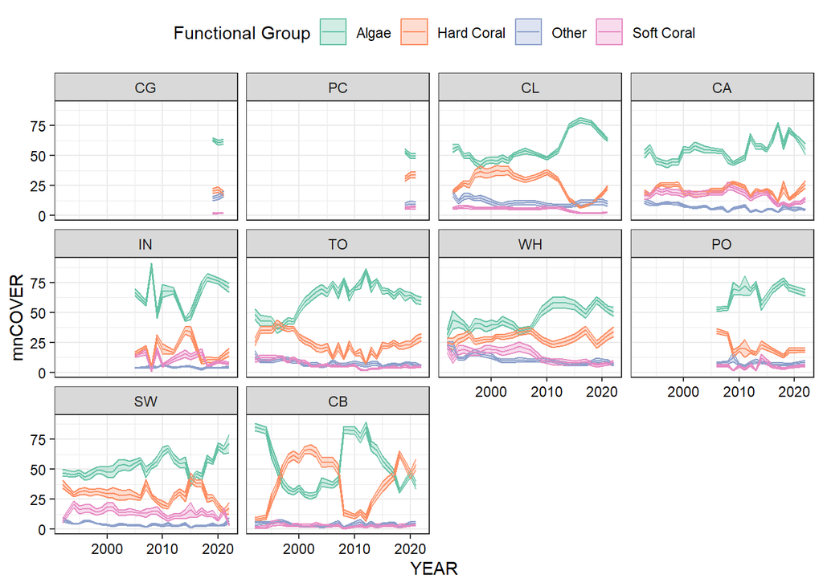

```r
ggplot(data = aims_summary,
aes(x = YEAR, y = mnCOVER, color = GROUP_CODE, fill = GROUP_CODE)) +
geom_ribbon(alpha = 0.3, aes(ymin = mnCOVER-sdCOVER/sqrt(nCOVER),
ymax = mnCOVER+sdCOVER/sqrt(nCOVER))) +
geom_line() +
scale_color_brewer(name = "Functional Group", palette = "Set2") +
scale_fill_brewer(name = "Functional Group", palette = "Set2") +
facet_wrap(~SECTOR) +
theme_bw() +
theme(legend.position = "top",
axis.text = element_text(color = "black"))
```

Re-summarize the data

```r
aims_summary <- aims %>%
  group_by(YEAR, SECTOR, SHELF, GROUP_CODE) %>% #what's different here?
  summarize(mnCOVER = mean(COVER, na.rm = TRUE),
            sdCOVER = sd(COVER, na.rm = FALSE),
            nCOVER = n())
```

Plot the functional group covers per sector and shelf (mean +/- SE) written with appropriate indents

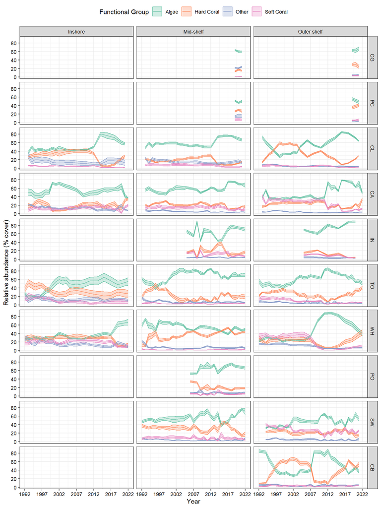

```r
ggplot(data = aims_summary,
       aes(x = YEAR, y = mnCOVER, color = GROUP_CODE, fill = GROUP_CODE)) +
  geom_ribbon(alpha = 0.3, aes(ymin = mnCOVER-sdCOVER/sqrt(nCOVER),
                               ymax = mnCOVER+sdCOVER/sqrt(nCOVER))) +
  geom_line() +
  scale_x_continuous(name = "Year", breaks = seq(1992,2022,5)) +
  scale_y_continuous(name = "Relative abundance (% cover)", breaks = seq(0,100,20)) +
  scale_color_brewer(name = "Functional Group", palette = "Set2") +
  scale_fill_brewer(name = "Functional Group", palette = "Set2") +
  facet_grid(rows = vars(SECTOR), cols = vars(SHELF),
             labeller = labeller(SHELF = c("I"="Inshore",
                                           "M"="Mid-shelf",
                                           "O"="Outer shelf"))) +
  theme_bw() +
  theme(legend.position = "top",
        axis.text = element_text(color = "black"))
```

Fourth, create nested sections with headings demarcated by pound signs. You can quickly navigate to sections using the outline or drop-down menu.

# # Heading 1

## ## Heading 2

### ### Heading 3

#### #### Heading 4

Finally, use consistent names and syntax for variables. It’s also a good idea to use different naming conventions for your **stored variables** (created in R and saved to the environment) vs. your **data frame variables** (the column headers).

There are five primary types of cases:

- Camel case: uses capital letters to delineate all words, except for the first word (e.g., newVariable)
- Pascal case: uses capital letters to delineate all words (e.g., NewVariable)
- Snake case: uses underscores to delineate all words (e.g., new_variable)
- Kebab case: uses hyphens to delineate all words (e.g., new-variable)
- Dot case: uses periods to delineate all words (e.g., new.variable)

I typically use snake case for stored data frames, camel case for other stored variables, and Pascal case for data frame variables.

## Code Development

Developing or writing code is like solving a puzzle: there are many possible solutions, but the process can be broken down into many dependent steps or modules. Thus, code should be modular, allowing for reordering and revision as necessary.

One of the most important things is to limit **hard-coding**, or embedding fixed values directly into your code. Instead, it’s a good idea to compute values dynamically or load them from external sources.

For example, if my threshold for low coral cover is 25%, I could hard code this.

```r
aims <- aims %>%
  mutate(LowCoral = if_else(GROUP_CODE == "Hard Coral" & COVER < 25, 1, 0))
```

Or I could create a variable for low coral cover that I can change as needed.

```r
lowCoral = 25

aims <- aims %>%
  mutate(LowCoral = if_else(GROUP_CODE == "Hard Coral" & COVER < lowCoral, 1, 0))
```

But more realistically, low coral is probably in reference to the amount of algae present per survey.

```r
aims2 <- aims %>%
  group_by(SECTOR, REEF_ID, SITE_NO, VISIT_NO, SAMPLE_DATE) %>%
  mutate(LowCoral = if_else(GROUP_CODE == "Hard Coral" &
                              COVER[GROUP_CODE == "Hard Coral"] <
                              COVER[GROUP_CODE == "Algae"], 1, 0)) %>%
  ungroup()
```

Determine the proportion of surveys with “low” coral cover for the two methods

```r
#Surveys where coral cover was below 25%
sum(aims$LowCoral)/nrow(filter(aims, GROUP_CODE == "Hard Coral"))
```

```
## [1] 0.5274576
```

```r
#Surveys where coral cover is less than algae cover
sum(aims2$LowCoral)/nrow(filter(aims2, GROUP_CODE == "Hard Coral"))
```

```
## [1] 0.8124294
```

Another important feature of well-written code is limited redundancy. For instance, if I want to create a time series for each site within each reef, I could write separate code for 103 figures, each with 3 panels for the 3 sites.

```r
length(unique(aims$REEF_ID))
```

```
## [1] 103
```

Or I could write a for-loop with a counter for reef ID. This way, I only need to modify the plot once to change it for all reefs.

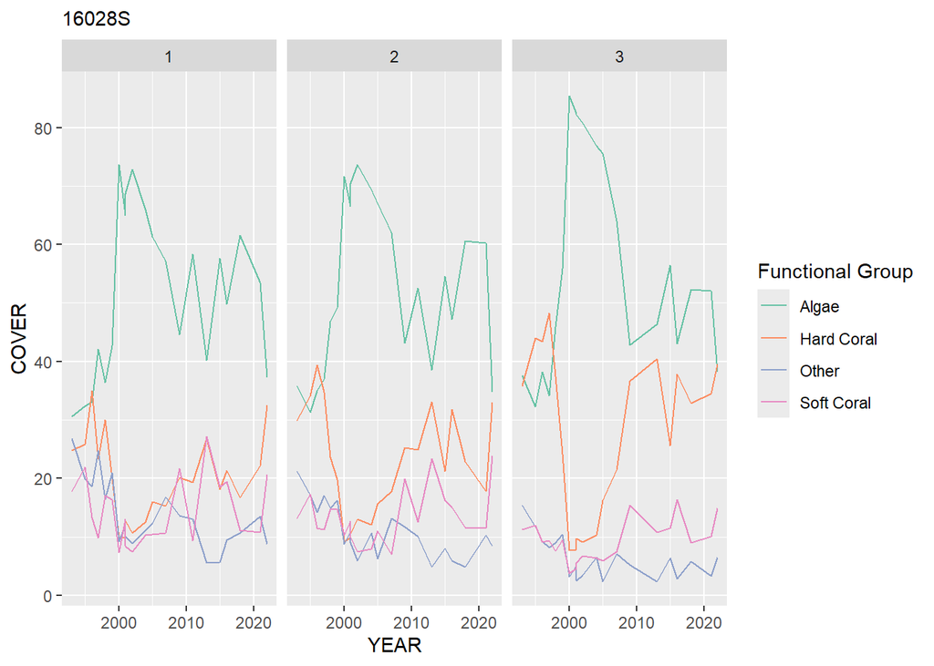

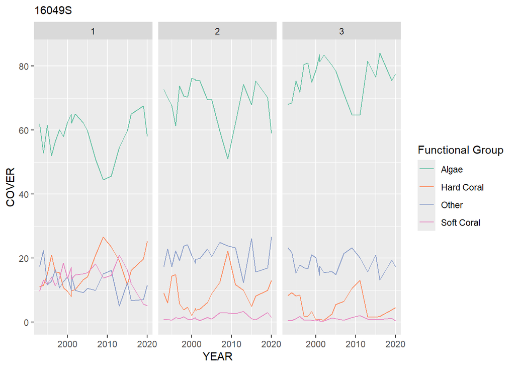

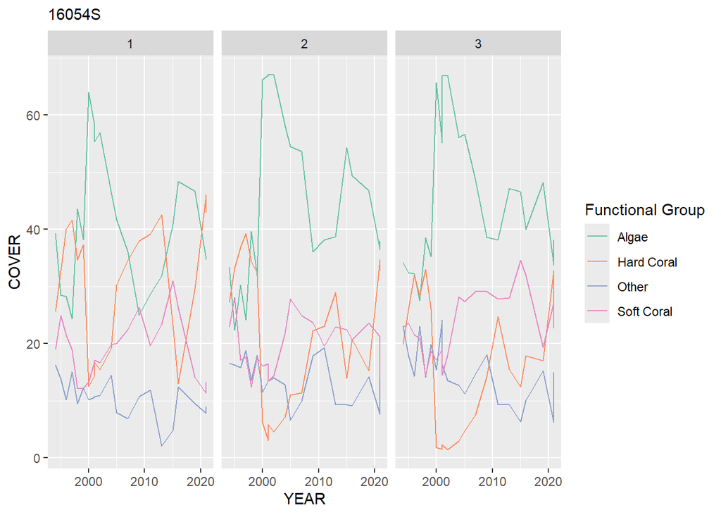

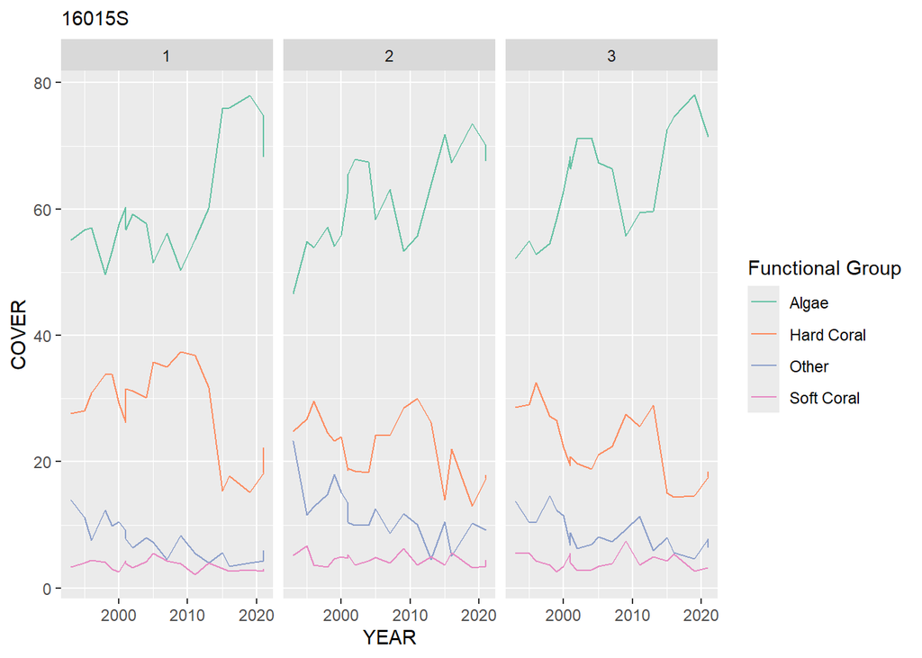

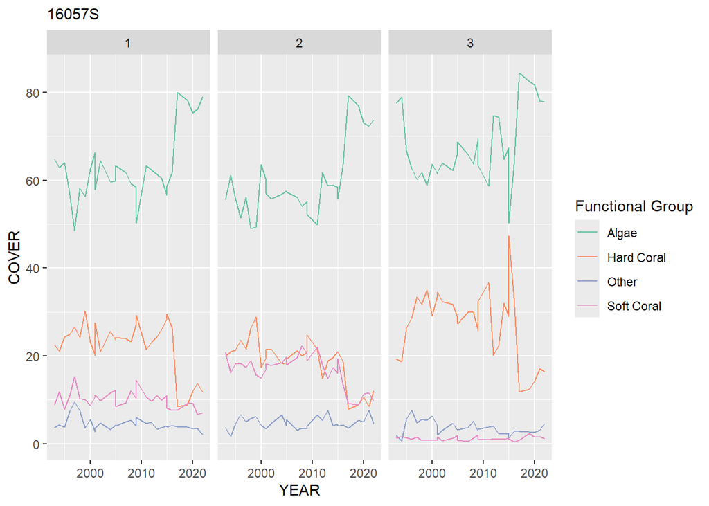

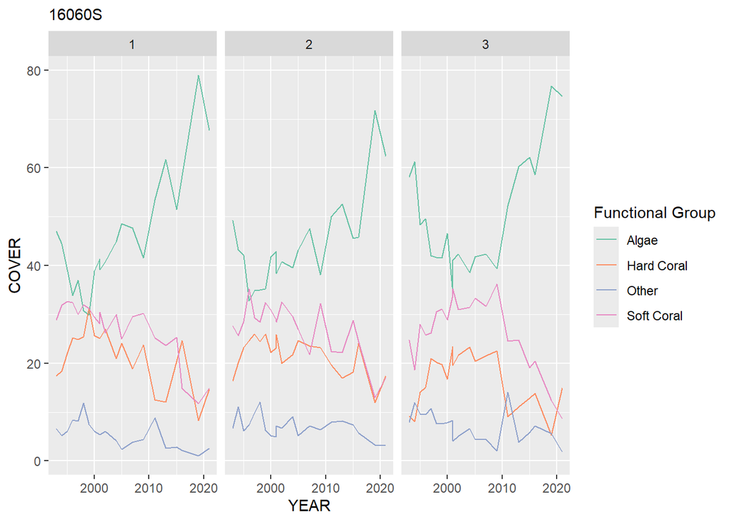

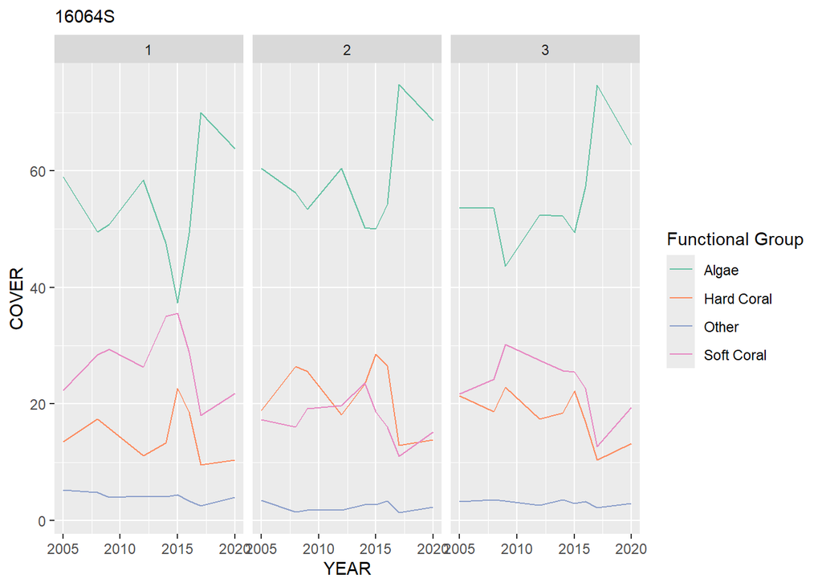

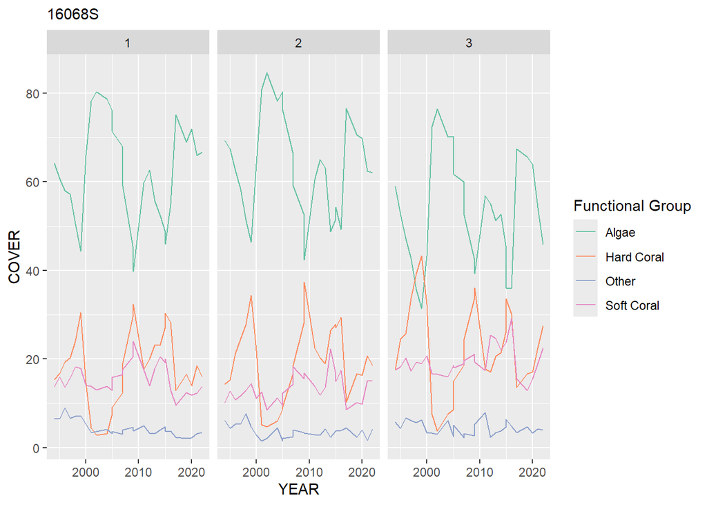

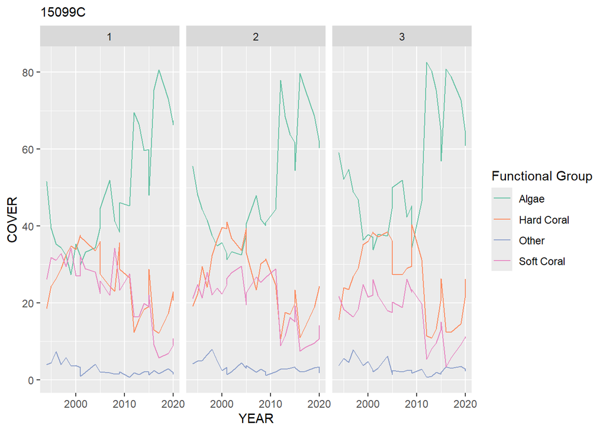

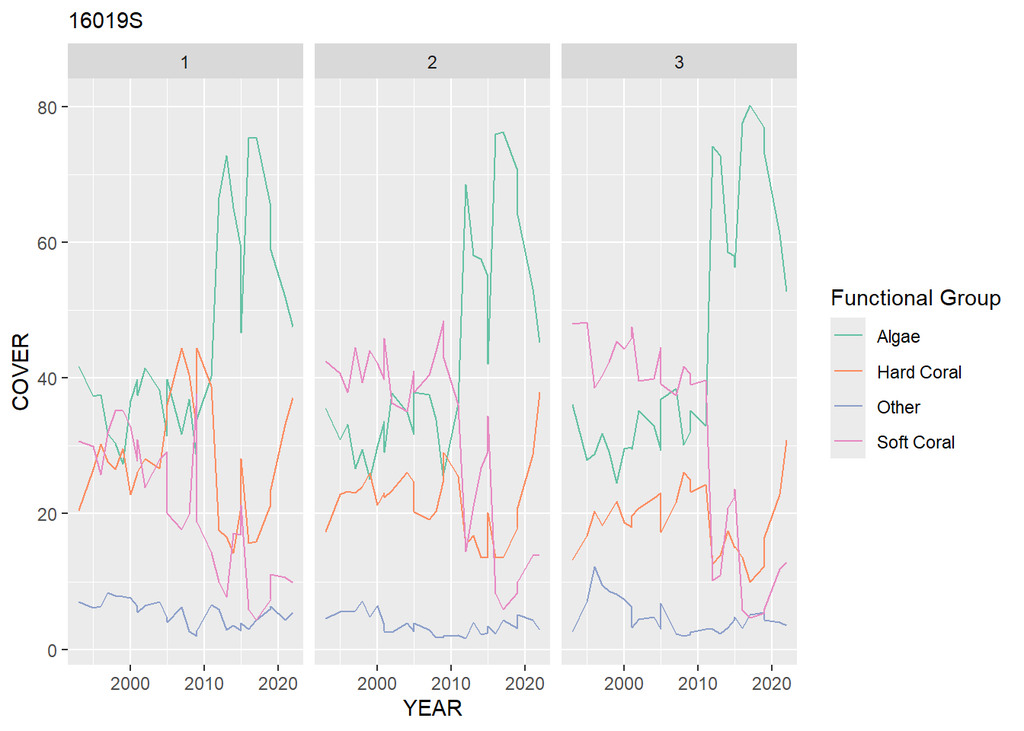

```r
for (i in 1:length(unique(aims$REEF_ID))) {
  reef = unique(aims$REEF_ID)[i]
  reefPlot <-
    ggplot(data = filter(aims, REEF_ID == reef),
           aes(x = YEAR, y = COVER, color = GROUP_CODE)) +
    geom_line() +
    scale_color_brewer(name = "Functional Group", palette = "Set2") +
    labs(subtitle = reef) +
    facet_wrap(~SITE_NO)

  if(i <= 10){
    print(reefPlot)
  }
}
```